# Cole Striler & Jenny Sokolsky

- Home
- Project Code
- Sources

```python
#imports
import pandas as pd
import numpy as np
import zipfile
import matplotlib.pyplot as plt
import seaborn as sns
from datetime import datetime


%matplotlib inline
```

# Green Media

Below is our code that we wrote for the project. We made it so that you can read through it in a sequence and the results are redundant with our discoveries on the Home page. This is basically us showing our thought process.

## Loading The Data

Our data set contains every article published by the Huffington Post from 2012 to 2018.

```python
news = pd.read_json("data/News_Category_Dataset_v2.json", lines=True)
news['date'] = pd.to_datetime(news['date'])
news['year'] = news['date'].dt.year
news['month'] = news['date'].dt.month
news['day'] = news['date'].dt.day
news.head()
```

|  | authors | category | date | headline | link | short_description | year | month | day |
| --- | --- | --- | --- | --- | --- | --- | --- | --- | --- |
| 0 | Melissa Jeltsen | CRIME | 2018-05-26 | There Were 2 Mass Shootings In Texas Last Week... | https://www.huffingtonpost.com/entry/texas-ama... | She left her husband. He killed their children... | 2018 | 5 | 26 |
| 1 | Andy McDonald | ENTERTAINMENT | 2018-05-26 | Will Smith Joins Diplo And Nicky Jam For The 2... | https://www.huffingtonpost.com/entry/will-smit... | Of course it has a song. | 2018 | 5 | 26 |
| 2 | Ron Dicker | ENTERTAINMENT | 2018-05-26 | Hugh Grant Marries For The First Time At Age 57 | https://www.huffingtonpost.com/entry/hugh-gran... | The actor and his longtime girlfriend Anna Ebe... | 2018 | 5 | 26 |
| 3 | Ron Dicker | ENTERTAINMENT | 2018-05-26 | Jim Carrey Blasts 'Castrato' Adam Schiff And D... | https://www.huffingtonpost.com/entry/jim-carre... | The actor gives Dems an ass-kicking for not fi... | 2018 | 5 | 26 |
| 4 | Ron Dicker | ENTERTAINMENT | 2018-05-26 | Julianna Margulies Uses Donald Trump Poop Bags... | https://www.huffingtonpost.com/entry/julianna-... | The "Dietland" actress said using the bags is ... | 2018 | 5 | 26 |

```python
news.describe()
```

|  | year | month | day |
| --- | --- | --- | --- |
| count | 200853.000000 | 200853.000000 | 200853.000000 |
| mean | 2014.611930 | 6.381682 | 15.698516 |
| std | 1.801049 | 3.432298 | 8.780830 |
| min | 2012.000000 | 1.000000 | 1.000000 |
| 25% | 2013.000000 | 3.000000 | 8.000000 |
| 50% | 2015.000000 | 6.000000 | 16.000000 |
| 75% | 2016.000000 | 9.000000 | 23.000000 |
| max | 2018.000000 | 12.000000 | 31.000000 |

## Simple EDA

Let's take a look at the different news categories and their relative frequencies. As you can see from the graph below, the most common articles are categorized as `politics` and the least common is `education`.

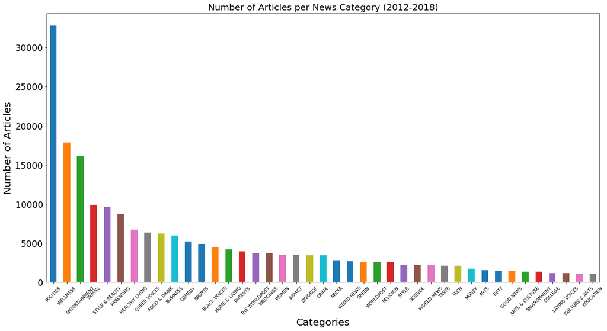

```python
plt.figure(figsize=(20,10))
news['category'].value_counts().plot(kind="bar")
plt.title("Number of Articles per News Category (2012-2018)", fontsize=18)
plt.xlabel("Categories", fontsize=20)
plt.ylabel("Number of Articles", fontsize=20)
plt.xticks(rotation=45, fontsize=9)
plt.yticks(fontsize=18)
plt.savefig("img/categories.jpg")
plt.show()
```

# Looking Deeper Into `ENVIRONMENT` and `GREEN`

The two news categories that are most relevant to this class are `ENVIRONMENT` and `GREEN`. We will explore these two categories more to see if there is anything we can learn from them.

## Finding Common Words in Headlines

```python
def eliminate_excess(series):
    """In news headlines, there are many excess punctuation.
    This function removes all of that."""
    punct_re = r'[^A-Za-z\d\s]'
    #series = series.apply(lambda x: x.replace("’", ""))
    series = series.str.replace(punct_re, " ")
    return series.str.lower()
```

```python
def count_frame(df, n):
    """Takes in a data frame and int n:

    DataFrame/ df: dataframe with HEADLINE column
    int/ n: number of words to choose
    r/type: 2 column dataframe most common words & counts"""

    counts = to_dict(df.headline)
    frame = pd.DataFrame.from_dict(counts, orient='index')
    frame = frame.sort_values(0, ascending=False).reset_index().head(n)
    frame = frame.rename(columns={'index': 'word', 0:'count'})
    return frame
```

```python
# cleaning columns
news.loc[:, 'headline'] = eliminate_excess(news['headline'])
news.loc[:, 'short_description'] = eliminate_excess(news['short_description'])

# making new DataFrames
env = news[(news['category']=='ENVIRONMENT')]
green = news[news['category']=='GREEN']
env_and_green = news[(news['category']=='GREEN') | (news['category']=="ENVIRONMENT")]

f"""There are {env.shape[0]} ENVIRONMENT articles and {green.shape[0]} GREEN articles"""
```

```
'There are 1323 ENVIRONMENT articles and 2622 GREEN articles'
```

```python
# all of the articles are from the huffington post
for i in np.arange(5):
    print(env.link.values[i])
```

```
https://www.huffingtonpost.com/entry/skyvetts-save-wild-lioness_us_5bb154b1e4b09bbe9a5eb04d
https://www.huffingtonpost.com/entry/animal-photos-of-the-week_us_5bb154c6e4b09bbe9a5eb10e
https://www.huffingtonpost.com/entry/washington-mudslide-salmon_us_5bb154c6e4b09bbe9a5eb129
https://www.huffingtonpost.com/entry/americas-exotic-pet-obsession_us_5bb154b0e4b09bbe9a5eb019
https://www.huffingtonpost.com/entry/carbon-climate-change_us_5bb154b3e4b09bbe9a5eb0c9
```

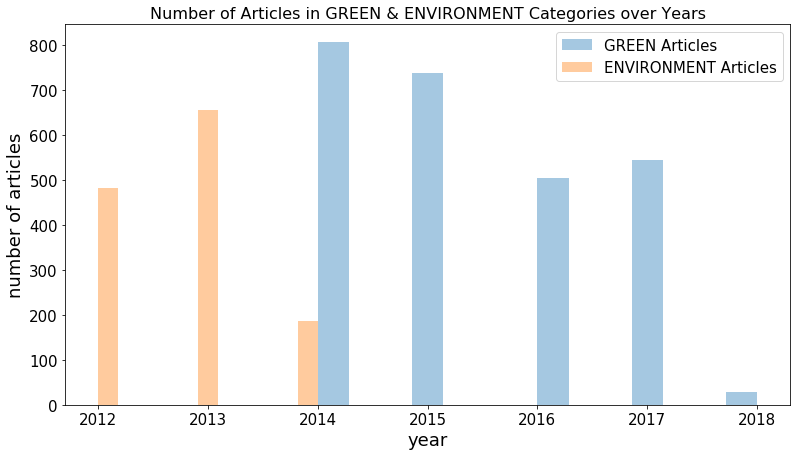

```python
plt.figure(figsize=(13,7))
sns.distplot(green['year'], hist=True, kde=False, label='GREEN Articles')
sns.distplot(env['year'], hist=True, kde=False, label='ENVIRONMENT Articles')
plt.title("Number of Articles in GREEN & ENVIRONMENT Categories over Years", size=16)
plt.xlabel('year', fontsize=18)
plt.ylabel('number of articles', fontsize=18)
plt.xticks(fontsize=15)
plt.yticks(fontsize=15)
plt.legend(fontsize=15)
plt.savefig("img/env_vs_green.jpg")
plt.show()
```

```python
# words that we will exclude from our model
stopwords = ["ourselves", "hers", "between", "yourself", "but", "again", "there", "about", "once",
             "during", "out", "very", "having", "with", "they", "own", "an", "be", "some", "for",
             "do", "its", "yours", "such", "into", "of", "most", "itself", "other", "off", "is", "s",
             "am", "or", "who", "as", "from", "him", "each","the", "themselves", "until", "below",
             "are", "we", "these", "your", "his", "through", "don", "nor", "me", "were", "her", "more",
             "himself", "this", "down", "should", "our", "their", "while", "above", "both", "up", "to",
             "ours", "had", "she", "all", "no", "when", "at", "any", "before", "them", "same", "and",
             "been", "have", "in", "will", "on", "does", "yourselves", "then", "that", "because", "what",
             "over", "why", "so", "can", "did", "not", "now", "under", "he", "you", "herself", "has",
             "just", "where", "too", "only", "myself", "which", "those", "i", "after", "few", "whom", "t",
             "being", "if", "theirs", "my", "against", "a", "by", "doing", "it", "how", "further", "was",
             "here", "than", "--"]
```

```python
def to_dict(series):
    """Takes in a pd.Series of Strings and
        1) Takes every string
        2) Splits into individual words
        3) Checks if word is a stopword
        4) if not a stopword, add it to a dictionary
        5) If it is already in the dictionary, add a count"""
    dic = {}
    array = series.values
    for num in range(len(array)):
        headline = array[num].split()
        for word in headline:
            if word not in stopwords:
                if word in dic:
                    dic[word] += 1
                else:
                    dic[word] = 0
    return dic
```

### Looking at `headline`s

```python
# ENVIRONMENT
env_headline_counts = count_frame(env, env.shape[0])
# GREEN
green_headline_counts = count_frame(green, green.shape[0])
green_headline_counts.head()
```

|  | word | count |
| --- | --- | --- |
| 0 | climate | 354 |
| 1 | change | 192 |
| 2 | california | 122 |
| 3 | dog | 113 |
| 4 | new | 101 |

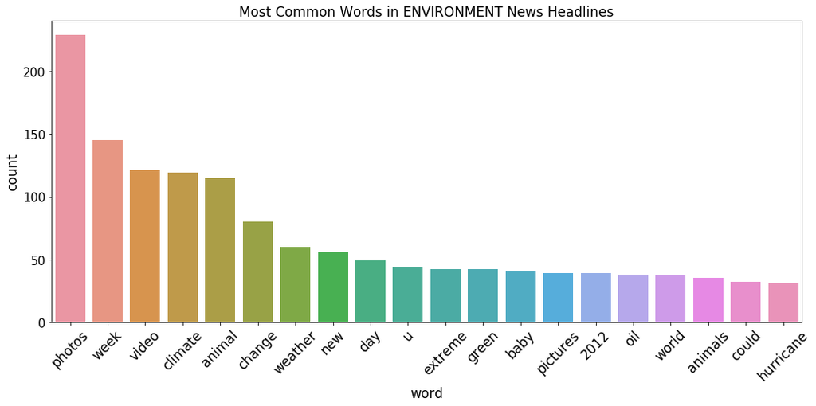

```python
top_20_env = env_headline_counts.head(20)

plt.figure(figsize=(17,7))
#top_20.plot(x='word', kind='bar')
sns.barplot(x='word', y='count', data = top_20_env)
plt.xticks(fontsize=17,rotation=45)
plt.title("Most Common Words in ENVIRONMENT News Headlines", fontsize=17)
plt.yticks(fontsize=15)
plt.xlabel(s='word', fontsize=17)
plt.ylabel(s='count', fontsize=17)
plt.show()
```

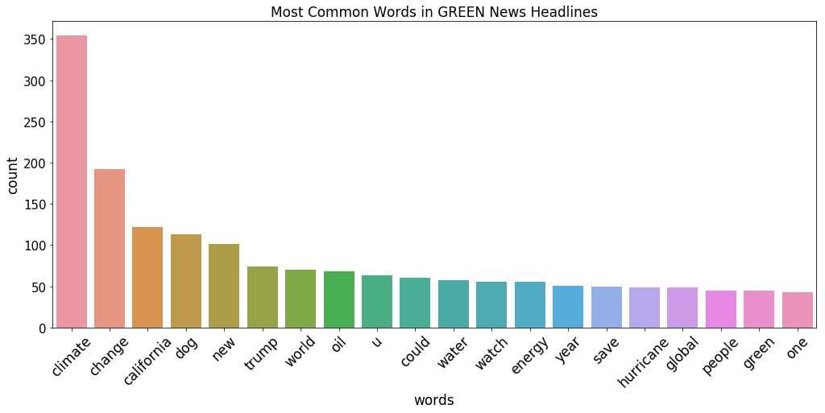

```python
top_20_green = green_headline_counts.head(20)

plt.figure(figsize=(17,7))
#top_20.plot(x='word', kind='bar')
sns.barplot(x='word', y='count', data = top_20_green)
plt.xticks(fontsize=17,rotation=45)
plt.title("Most Common Words in GREEN News Headlines", fontsize=17)
plt.yticks(fontsize=15)
plt.xlabel(s='words', fontsize=17)
plt.ylabel(s='count', fontsize=17)
plt.show()
```

### Looking at `short_description`

```python
# now looking at article description
desc_counts = to_dict(env.short_description)
description_counts = pd.DataFrame.from_dict(desc_counts, orient='index')
description_counts = description_counts.sort_values(0, ascending=False).reset_index()
description_counts = description_counts.rename(columns={'index': 'word', 0:'count'})
description_counts.head()
```

|  | word | count |
| --- | --- | --- |
| 0 | week | 133 |
| 1 | climate | 118 |
| 2 | animal | 98 |
| 3 | one | 98 |
| 4 | world | 97 |

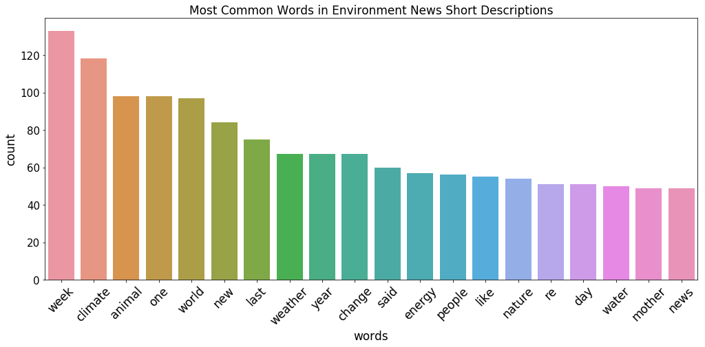

```python
top_20 = description_counts.head(20)

plt.figure(figsize=(17,7))
#top_20.plot(x='word', kind='bar')
sns.barplot(x='word', y='count', data = top_20)
plt.xticks(fontsize=17,rotation=45)
plt.title("Most Common Words in Environment News Short Descriptions", fontsize=17)
plt.yticks(fontsize=15)
plt.xlabel(s='words', fontsize=17)
plt.ylabel(s='count', fontsize=17)
plt.show()
```

```python
for i in range(5):
    print(env.short_description.values[i])
    print(env.link.values[i])
    print("_____________________________________________________________________________________________________________________")
```

```
warning  this video contains graphic images of a lion injured by a buffalo  whether you love wild animals or just enjoy stories
https://www.huffingtonpost.com/entry/skyvetts-save-wild-lioness_us_5bb154b1e4b09bbe9a5eb04d
_____________________________________________________________________________________________________________________
this week has been an interesting one in the weird  wild world of animal news  thousands of dog lovers are gearing up for
https://www.huffingtonpost.com/entry/animal-photos-of-the-week_us_5bb154c6e4b09bbe9a5eb10e
_____________________________________________________________________________________________________________________
the tribe   whose name means  the river people    welcomes the arrival of migrating fish in a  first salmon  ceremony and
https://www.huffingtonpost.com/entry/washington-mudslide-salmon_us_5bb154c6e4b09bbe9a5eb129
_____________________________________________________________________________________________________________________
nearly two thirds of americans own at least one cat or dog  and that s considered an accepted cultural practice  but exotic
https://www.huffingtonpost.com/entry/americas-exotic-pet-obsession_us_5bb154b0e4b09bbe9a5eb019
_____________________________________________________________________________________________________________________
but break ups happen all the time and we find ways to move on and survive  we make choices to make our lives better for the future  i think it is time to admit that as a society we need to break up with our bad boyfriend  carbon
https://www.huffingtonpost.com/entry/carbon-climate-change_us_5bb154b3e4b09bbe9a5eb0c9
_____________________________________________________________________________________________________________________
```

# News Polarity

```python
index = pd.read_table('vader_lexicon.txt', header = None).iloc[:, 0]
polarity = {'polarity': pd.read_table('vader_lexicon.txt', header = None).iloc[:, 1]}
sent = pd.DataFrame(data = polarity).set_index(index)
sent.index.name = None

assert isinstance(sent, pd.DataFrame)
assert sent.shape == (7517, 1)
assert list(sent.index[5000:5005]) == ['paranoids', 'pardon', 'pardoned', 'pardoning', 'pardons']
assert np.allclose(sent['polarity'].head(), [-1.5, -0.4, -1.5, -0.4, -0.7])

punct_re = r'[^A-Za-z\d\s]'
news['hdl_no_punct'] = news['headline'].str.replace(punct_re, " ")
news['desc_no_punct'] = news['short_description'].str.replace(punct_re, " ")

tidy_format = news['desc_no_punct'].str.split(expand=True).stack().to_frame().reset_index(level = 1)
tidy_format.columns = ["num", "word"]
tidy_format.head()
```

|  | num | word |
| --- | --- | --- |
| 0 | 0 | she |
| 0 | 1 | left |
| 0 | 2 | her |
| 0 | 3 | husband |
| 0 | 4 | he |

```python
# Adding Polarity to NEWS table
news.loc[:, 'polarity'] = (tidy_format.merge(sent, left_on = 'word',
                                       right_index = True)['polarity']
                                        .reset_index().groupby('index').sum())
news.loc[:, 'polarity'].replace(np.float64('nan'), 0, inplace = True)

# Adding Polarity to ENVIRONMENT table
env.loc[:, 'polarity'] = (tidy_format.merge(sent, left_on = 'word',
                                       right_index = True)['polarity']
                                        .reset_index().groupby('index').sum())
env.loc[:, 'polarity'].replace(np.float64('nan'), 0, inplace = True)

# Adding Polarity to GREEN table
green.loc[:, 'polarity'] = (tidy_format.merge(sent, left_on = 'word',
                                       right_index = True)['polarity']
                                        .reset_index().groupby('index').sum())
green.loc[:, 'polarity'].replace(np.float64('nan'), 0, inplace = True)

# Adding Polarity to ENV_AND_GREEN table
# Adding Polarity to GREEN table
env_and_green.loc[:, 'polarity'] = (tidy_format.merge(sent, left_on = 'word',
                                       right_index = True)['polarity']
                                        .reset_index().groupby('index').sum())
env_and_green.loc[:, 'polarity'].replace(np.float64('nan'), 0, inplace = True)
```

```python
# taking the 100 most positive/negative headlines and putting in dictionary
most_positive = env_and_green.sort_values('polarity', ascending=False)
most_negative = env_and_green.sort_values('polarity', ascending=True)

most_positive_counts = count_frame(most_positive, 20)
most_negative_counts = count_frame(most_negative, 20)
```

[figure not shown]

```python
plt.figure(figsize=(17,7))
sns.barplot(x='word', y='count', data = most_positive_counts)
plt.xticks(fontsize=17,rotation=45)
plt.title("Most Common Words in Top 200 Most Positive Headlines", fontsize=17)
plt.yticks(fontsize=15)
plt.xlabel(s='words', fontsize=17)
plt.ylabel(s='count', fontsize=17)
plt.show()
```

[figure not shown]

```python
plt.figure(figsize=(17,7))
sns.barplot(x='word', y='count', data = most_negative_counts)
plt.xticks(fontsize=17,rotation=45)
plt.title("Most Common Words in Top 200 Most Negative Headlines", fontsize=17)
plt.yticks(fontsize=15)
plt.xlabel(s='words', fontsize=17)
plt.ylabel(s='count', fontsize=17)
plt.show()
```

```python
print("MOST POSITIVE HEADLINES THAT CONTAIN THE WORD CLIMATE:")
print(most_positive[most_positive['headline'].str.contains("climate")].headline.values[:10])
print("- - - - - -  - - - - - - - - - - - - - - - - - - - - - - - - - - - - - - - - - - - - - -")
print("MOST NEGATIVE HEADLINES THAT CONTAIN THE WORD CLIMATE:")
print(most_negative[most_negative['headline'].str.contains("climate")].headline.values[:10])
```

```
MOST POSITIVE HEADLINES THAT CONTAIN THE WORD CLIMATE:
[ '8 ways that california and china can work together to reduce pollution and protect the climate'
 'climate summit  creating better and more sustainable cities'
 'it s time to fix the climate    why do we delay '
 'flood tide for the climate movement'
 'climate crisis is every working person s crisis'
 'climate change and rights talk'
 'we won t back down  bloomberg philanthropies  sierra club announce increased commitment to retiring coal  fighting climate change'
 'climate change this week  a break for clean energy  2012 hottest yet  gravitylight  and more '
 'from the holy father to every father  our kids need us to act on climate change'
 'throwing a wrench in the climate denial machine']
- - - - - -  - - - - - - - - - - - - - - - - - - - - - - - - - - - - - - - - - - - - - -
MOST NEGATIVE HEADLINES THAT CONTAIN THE WORD CLIMATE:
['youth for climate' 'taking climate action for  and with  women'
 'a climate cure for social injustice'
 'climate change and the record 2014 california drought'
 'a call to action on climate for all candidates for president of the united states'
 'life as a climate refugee'
 'climate change doesn t care if you re republican or democrat'
 'climate crisis a public health emergency too  why nurses will join climate march sept  21'
 'how the media can improve their climate coverage'
 'lord stern   why are we waiting  the urgency   promise of tackling climate change ']
```

We can also look at the change in polarity over time. Below, we plot the change in polarity in ENVIRONMENT and GREEN news articles (from `env_and_green`). As you see, since 2013, news polarity has decreased (gotten more negative) in these two categories. In fact, in 2017 we see a massive drop in polarity. Let's explore what caused this drop.

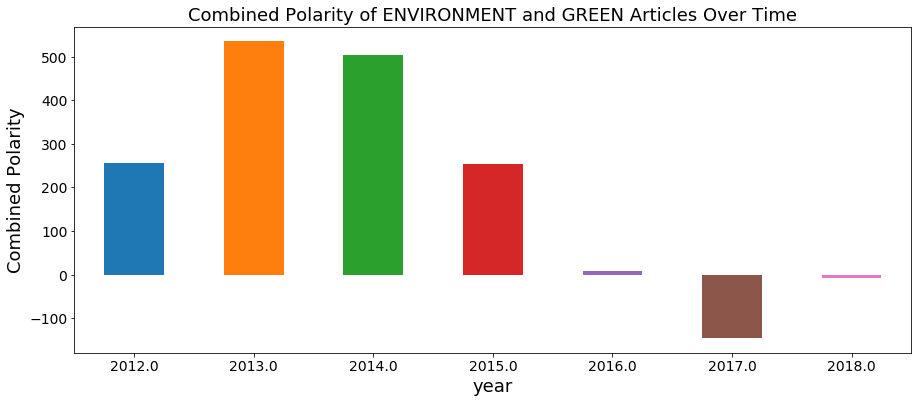

```python
# Change in polarity over time
plt.figure(figsize=(15,6))
news.groupby([env_and_green["year"]]).sum()['polarity'].plot(kind="bar")
plt.title("Combined Polarity of ENVIRONMENT and GREEN Articles Over Time", fontsize=18)
plt.xlabel('year', fontsize=18)
plt.xticks(fontsize=14, rotation='0')
plt.ylabel('Combined Polarity', fontsize=18)
plt.yticks(fontsize=14)
plt.savefig('img/polarity_years.jpg')
plt.show()
```

## Negative 2017

This result is pretty interesting. Let's take a look into why 2017 had such negative news articles

```python
env_green_2017 = env_and_green[env_and_green['year']==2017]
```

```python
# Make count frame
counts_2017_frame = count_frame(env_green_2017, 20)
counts_2017_frame.head()
```

|  | word | count |
| --- | --- | --- |
| 0 | climate | 85 |
| 1 | trump | 55 |
| 2 | california | 50 |
| 3 | change | 44 |
| 4 | harvey | 23 |

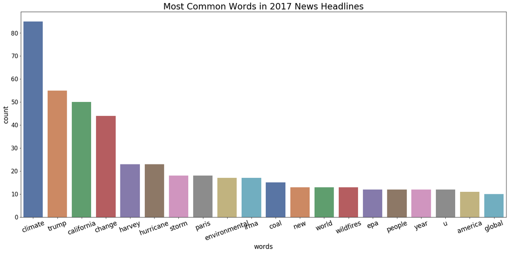

```python
plt.figure(figsize=(23,10))
sns.barplot(x='word', y='count', data = counts_2017_frame, palette="deep")
plt.xticks(fontsize=17,rotation=20)
plt.title("Most Common Words in 2017 News Headlines", fontsize=23)
plt.yticks(fontsize=15)
plt.xlabel(s='words', fontsize=17)
plt.ylabel(s='count', fontsize=17)
plt.savefig("img/2017_headlines.jpg")
plt.show()
```

### Words that stand out:

**Trump**, **Hurricane**, **Harvey**, **Irma**, **Wildfires**

Jan 1, 2017 was Trump's first day in office.

## Positive 2013

We can also see if we can figure out why 2013 had such positive ratings.

```python
env_green_2013 = env_and_green[env_and_green['year']==2013]
```

```python
counts_2013_frame = count_frame(env_green_2013, 20)
```

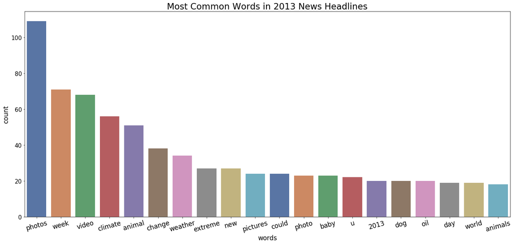

```python
plt.figure(figsize=(23,10))
sns.barplot(x='word', y='count', data = counts_2013_frame, palette="deep")
plt.xticks(fontsize=17,rotation=15)
plt.title("Most Common Words in 2013 News Headlines", fontsize=23)
plt.yticks(fontsize=15)
plt.xlabel(s='words', fontsize=17)
plt.ylabel(s='count', fontsize=17)
plt.savefig("img/2013_headlines.jpg")
plt.show()
```

## Let's See if We Can Guess the Political Bias of Hiffington Post

```python
# make new dataframes for TRUMP & OBAMA
trump = env_and_green[env_and_green['headline'].str.contains("trump")]
obama = env_and_green[env_and_green['headline'].str.contains("obama")]
presidents = env_and_green[(env_and_green['headline'].str.contains("obama")) | env_and_green['headline'].str.contains("trump")]
presidents.loc[:, "contains_trump"] = presidents['headline'].str.contains('trump')

# mean polarity of each president
trump_mean = '%.3f'%np.mean(trump.polarity)
obama_mean = '%.3f'%np.mean(obama.polarity)
```

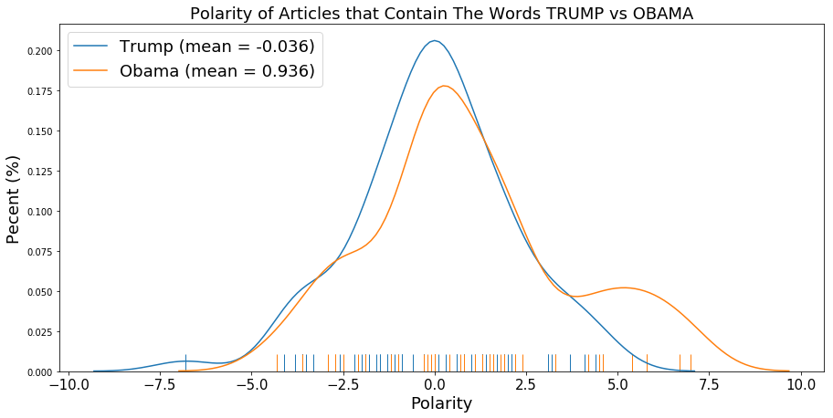

```python
plt.figure(figsize=(15,7))
sns.distplot(trump['polarity'], hist=False, label=f"Trump (mean = {trump_mean})", rug=True)
sns.distplot(obama['polarity'], hist=False, label=f"Obama (mean = {obama_mean})", rug=True)
plt.title("Polarity of Articles that Contain The Words TRUMP vs OBAMA", fontsize=18)
plt.xlabel("Polarity", fontsize=18)
plt.xticks(fontsize=15)
plt.ylabel("Pecent (%)", fontsize=18)
plt.legend(fontsize=18, loc=2)
plt.savefig("img/political_bias.jpg")
plt.show()
```

As you can see, articles that contain the word "OBAMA" have an average polarity of 0.936 (more positive) and articles that contain the word "TRUMP" have an average polarity of -0.036 (slightly more negative). Therefore, we predict that the Huffington Post is a more liberal news source. It turns out, after a quick Google search, we were right. The Huffington Post is a leftward-leaning news source.

```python
trump.year.value_counts()
```

```
2017    57
2016    16
2018     1
2015     1
2014     1
Name: year, dtype: int64
```

```python
obama.year.value_counts()
```

```
2016    11
2013    11
2015     9
2014     7
2012     5
2017     1
Name: year, dtype: int64
```

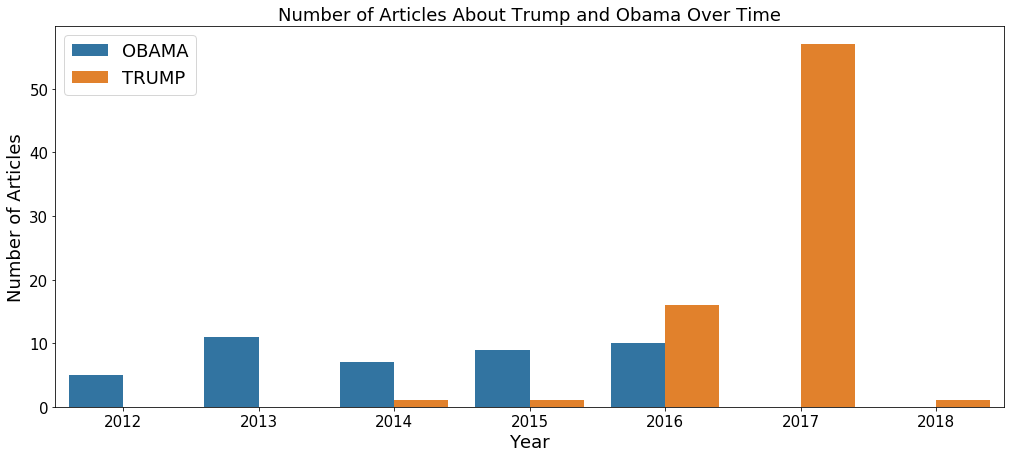

```python
plt.figure(figsize=(17,7))
sns.countplot(presidents.year, hue = presidents.contains_trump)
#sns.countplot(obama.year, color='b', label="Obama")
#p1 = plt.bar(trump.year, trump.groupby("year").sum(), width=.4, color='r')
#p2 = plt.bar(obama.year, obama.groupby("year").sum(), width=.4, bottom=trump.polarity, color='b')
#plt.hist(obama.year, color="r", label="Obama")
plt.title("Number of Articles About Trump and Obama Over Time", fontsize=18)
plt.xlabel("Year", fontsize=18)
plt.xticks(fontsize=15)
plt.ylabel("Number of Articles", fontsize=18)
plt.yticks(fontsize=15)
plt.legend(("OBAMA", "TRUMP"), fontsize=18, loc=2)
plt.savefig("img/presidents_over_time.jpg")
plt.show()
```

```python
import matplotlib.axes
from matplotlib.axes import Axes
```

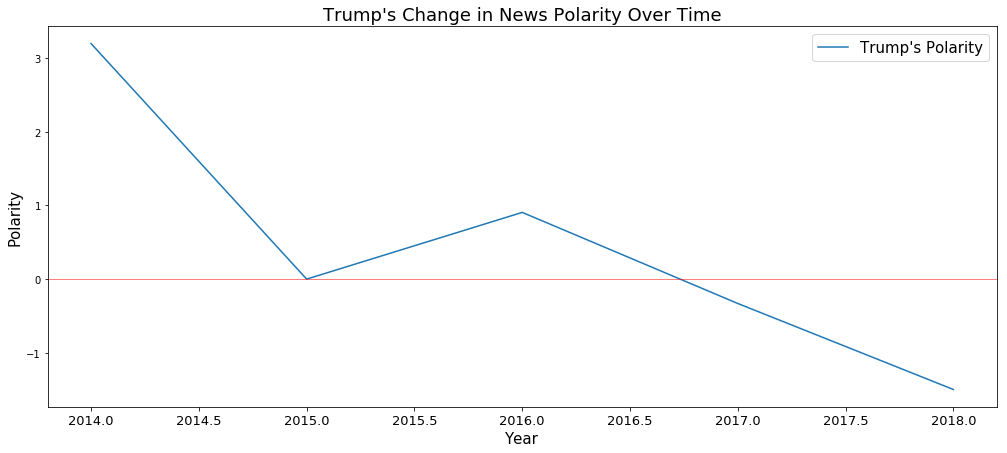

```python
plt.figure(figsize=(17,7))
sns.lineplot(x="year", y="polarity", data=trump, n_boot=0, label="Trump's Polarity")
#sns.lineplot(x="year", y="polarity", data=obama, n_boot=0, label="Obama")
plt.title("Trump's Change in News Polarity Over Time", fontsize=18)
plt.xticks(fontsize=13)
plt.xlabel("Year", fontsize=15)
plt.ylabel("Polarity", fontsize=15)
plt.xticks( fontsize=13)
plt.legend(fontsize=15)
plt.axhline(y=0, lw=0.5, color='r')
plt.savefig("img/trump.jpg")
plt.show()
```